# Create synthetic (and strongly reduced) version of GESIS Panel wave ja and jc

Author

Bernd Weiss

Published

November 16, 2023

## Preamble

For more information about the dataset, the documentation (codebook, wave report etc.) and how to obtain it, see https://www.gesis.org/en/gesis-panel/data.

**Warning**

Important: “Synthetic version” means that we provide a version of the datset that (mostly) looks and feels like the original dataset BUT it cannot be used for any serious scientific work.

The synthetic version of the datset has been created using the synthpop package: https://cran.r-project.org/web/packages/synthpop/index.html.

Load packages:

```r
library(synthpop)
library(haven)
library(tidyverse)
library(quarto)
```

## Load datasets, create subset, and convert variables

Load most recent (as of Nov 5th, 2023) version of GESIS Panel dataset (wave jc) and reduce its size drastically:

```r
source("ZA5664-65_merge-and-append-files.R")

# jcza003a: Participation, dichotomous and AAPOR code indicating complete or
# mostly complete interview
dfx_jc <- datc %>% filter(jcza003a == 1 & jcza006a %in% c(11, 12)) %>%
  select(z000001a:z000012c, starts_with("jc") | starts_with("ja"))
```

Load demographic dataset to add some basic sociodemographic variables:

```r
dfx_demo <- read_dta(file.path("J:", "Work", "GESISPanel", "03_daten",
                               "masterdatensatz", "ZA5665_GESIS_Panel_v49-0-0",
                               "data", "stata",
                               "ZA5665_demography_v49-0-0.dta"))
```

Reduce demographic dataset to wave jc:

```r
dfx_demo_jc <- dfx_demo %>%
  filter(wave == "jc") %>%
  select(-c("z000002a", "z000003a", "z000005a"))
dim(dfx_demo_jc)
```

```
[1] 5145   26
```

Join both datasets:

```r
dfx_final_joined <- dfx_demo_jc %>% left_join(., dfx_jc, by = "z000001a")
dim(dfx_final_joined)
```

```
[1] 5145  782
```

Declare missing values:

```r
dfx_final_joined[dfx_final_joined < 0] <- NA
```

Create final data set that will be used to create the synthetic dataset. For the synthpop package to work properly, a few variables need to be converted to factors. The result is stored in a data.frame since synthpop does not like tibbles:

```r
dfx_final <- dfx_final_joined %>%
  select(z000001a:z000012c, jczf001a:jczf007a, sex, yob, hle, marstat,
         jazc039a,
         jczq009a, jczf030a:jczf039a, jczj074a, jczj075a, jczj079a, jcdu080a,
         jcdu081a, jcdu082a, jcct087a) %>%
  select(-ends_with("_flag") & -ends_with("_orig"),
         -c(invmode, partmode, aapor),
         -c(z000003a:z000012c)) %>%
  mutate_at(vars(sex, hle, marstat,
               jczf001a:jczf007a,
               jazc039a,
               jczq009a, jczf030a:jczf039a, jczj074a, jczj075a, jczj079a, jcdu080a,
               jcdu081a, jcdu082a, jcct087a), list(factor)) %>%
  labelled::remove_val_labels() %>%
as.data.frame()
names(dfx_final)
```

```
 [1] "z000001a" "t"        "wave"     "year"     "cohort"   "sex"
 [7] "yob"      "hle"      "pinc"     "hhinc"    "marstat"  "z000002a"
[13] "jczf001a" "jczf002a" "jczf003a" "jczf004a" "jczf005a" "jczf006a"
[19] "jczf007a" "jazc039a" "jczq009a" "jczf030a" "jczf031a" "jczf032a"
[25] "jczf033a" "jczf034a" "jczf035a" "jczf036a" "jczf037a" "jczf038a"
[31] "jczf039a" "jczj074a" "jczj075a" "jczj079a" "jcdu080a" "jcdu081a"
[37] "jcdu082a" "jcct087a"
```

## Create synthetic version of dataset

Then, apply the `syn` command creating a synthetic version of the dataset. Note, `syn` returns a list containing a `data.frame` object (also called `syn`), which then is assigned to `dfx_synth`:

```r
dfx_synth_list <- syn(dfx_final, seed = 364624)
```

[output not shown]

```r
dfx_synth <- dfx_synth_list[["syn"]]
```

```r
dim(dfx_final_joined)
```

```
[1] 5145  782
```

```r
dim(dfx_synth)
```

```
[1] 5145   38
```

```
Comparing percentages observed with synthetic
```

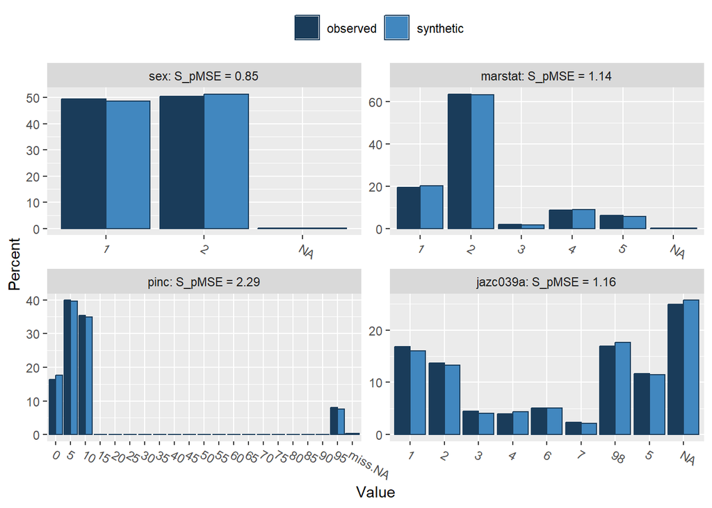

```
Selected utility measures:
             pMSE   S_pMSE df
sex      0.000021 0.847981  2
marstat  0.000069 1.139782  5
pinc     0.000139 2.287727  5
jazc039a 0.000113 1.162175  8
```

```r
options(repr.plot.width = 100, repr.plot.height = 10.75, repr.plot.res = 100)
compare(dfx_synth_list, dfx_final, vars = c("sex", "marstat", "pinc",
                                            "jazc039a"))
```

```r
head(dfx_final[1:5, 1:5])
```

```
   z000001a  t wave year cohort
1 100235501 59   jc 2022      1
2 100762801 59   jc 2022      1
3 101172701 59   jc 2022      1
4 101230001 59   jc 2022      1
5 102003501 59   jc 2022      1
```

```r
head(dfx_synth[1:5, 1:5])
```

```
   z000001a  t wave year cohort
1 586158402 59   jc 2022      1
2 506037403 59   jc 2022      3
3 237061904 59   jc 2022      2
4 777511302 59   jc 2022      1
5 492976901 59   jc 2022      2
```

```r
cor(as.numeric(dfx_final$jczf001a), as.numeric(dfx_final$jczf007a), use = "complete.obs")
```

```
[1] -0.07257585
```

```r
cor(as.numeric(dfx_synth$jczf001a), as.numeric(dfx_synth$jczf007a), use = "complete.obs")
```

```
[1] -0.08500776
```

## Export synthetic dataset

Note, in order to export the synthetic version, the list object needs to be provided. Also, the data will be exported as Stata as well as csv file.

```r
write.syn(dfx_synth_list, file = "ZA5665_GESIS_Panel_v49-0-0_Stata14_synthetic-data",
            filetype = "Stata", save.complete = FALSE)
```

```
Synthetic data exported as Stata file(s).
Information on synthetic data written to
  O:/projects/confer/ps2023-11_gesis_repro-research-ws/data/synthesis_info_ZA5665_GESIS_Panel_v49-0-0_Stata14_synthetic-data.txt
```

```r
write.syn(dfx_synth_list, file = "ZA5665_GESIS_Panel_v49-0-0_CSV_synthetic-data",
            filetype = "csv", save.complete = FALSE)
```

```
Synthetic data exported as csv file(s).
Information on synthetic data written to
  O:/projects/confer/ps2023-11_gesis_repro-research-ws/data/synthesis_info_ZA5665_GESIS_Panel_v49-0-0_CSV_synthetic-data.txt
```

```r
renderthis::to_pdf("create-gesis-panel-jc-synth.html")
```

```
ℹ Rendering 'create-gesis-panel-jc-synth.html' into create-gesis-panel-jc-synth…
```

```
✔ Rendering 'create-gesis-panel-jc-synth.html' into create-gesis-panel-jc-synth…
```

```r
# quarto_serve("documentation/rr23-gp-synth-codebook.qmd")
```